Handwritten Digit Recognition with ARDIS Data

Jinhyun Kwon

Summary

This project created classiﬁcation models for the handwritten digit images of the ARDIS dataset, which is

publicly available on the ARDIS GitHub website (https://ardisdataset.github.io/ARDIS/). Speciﬁcally, this

project focused on analysis of the 7,600 handwritten digit images taken from the ARDIS III dataset.

The images were processed in R using the ‘magick’ package, ﬂattened into rows, and compiled into a single

dataframe to be exported as a CSV ﬁle. We created three datasets corresponding to images with three pixel

resolutions: 12x12, 20x20, and 32x32, denoted as img_12, img_20, and img_32. Dimensional reduction

was applied to the 32x32 image dataset with principal components analysis (PCA). The ﬁrst 286 principal

components, which explained 90% of the variance, were extracted and stored in a separate dataset.

searching by cross-validation was used to tune each model; tuning was completed with the ’caret’ package’s

’train()’ function.

The best model for the img_12 dataset was the random forest model with 12 variables per tree; the test

error for this model was 0.0367. The random forest model was also the best model for the img_20 dataset,

giving a similar test error of 0.04. For the PCA data, the best model was the KNN model with K=1, which

produced a test error of 0.0467.

speed and eﬃciency without signiﬁcant loss of information or accuracy.

1

Introduction

Perhaps one of the most familiar applications of machine learning is image recognition technology. Facial

recognition technology is an oft-cited, yet especially controversial, example of the most practical, powerful

applications of contemporary machine learning innovations. Computers have neither the eyes nor the complex

brain structures that humans use to look at and recognize objects; to computers, images are just large matrices

of numbers. Nevertheless, researchers have devised a miscellany of predictive techniques that, combined with

exponential improvements in computing technology, has achieved a striking level of precision in computer

vision.

This project explores an elementary implementation of computer image recognition: handwritten digit

identiﬁcation. More speciﬁcally, the interest of this project is to apply some more basic statistical learning

techniques to a handwritten historical digit data called ARDIS (Arkiv Digital Sweden). The ARDIS data is

composed of JPG images of Arabic numeral samples extracted from over 15,000 diﬀerent nineteenth and

twentieth century Swedish church records; the records were maintained by a number of diﬀerent priests, each

possessing his own calligraphic idiosyncrasies. The data itself was gathered by the Department of Computer

Science from the Blekinge Institute of Technology in Karlskrona, Sweden and remains publicly available in

several formats on the ARDIS Github website (https://ardisdataset.github.io/ARDIS/). The dataset that

this project analyzes is the ARDIS III dataset, which contains 7,600 handwritten digit images with minimal

background noise—760 images per digit (0-9).

Image Processing

The ARDIS GitHub supplies four diﬀerent datasets, three of which include the digit images in varying formats

and one of which contains pre-processed numeric data on the digit images. We decided that, for the purpose

of this project, the ARDIS III dataset comprised of individual digit images with minimal noise strikes an

optimal balance between convenience and complexity—while we do not have to worry about cleaning up

the images or identifying strings of digits, we do have to format these raw images as a numeric matrix to

properly apply our classiﬁcation methods. Processing these images ourselves also allowed us to consider how

recognition accuracy suﬀers at the cost of computational ease aﬀorded by decreased pixel resolution.

R, by no means the best program for handling images, nonetheless provides suﬃcient support for basic

manipulation; the ‘magick’ package, a wrapper of ImageMagick for R, includes the simple image reading,

rescaling, and recoloring functions that we required. We wrote two functions, ’convert_to_row()’ and

’ardis_data(),’ that completed the entire process of reading, editing, and ﬂattening images into a single data

set.

The ’convert_to_row()’ function takes two parameters: img, an image object, and res, an integer representing

the image resolution. Given the resolution, this function re-scales the image, converts all the pixel colors

to either #ﬀﬀﬀ or #000000 (white or black), changes those color values to 1 or 0, and ﬁnally collapses the

image matrix into a single row.

The ’ardis_data()’ function, given a 0-9 digit and resolution, applies the ’convert_to_row()’ function with

the speciﬁed resolution to the 760 images of the given digit and gathers them into a single data frame.

The full 7,600 row datasets were created by applying the ’ardis_data()’ function ten times, once for each

digit, and then exported as CSV ﬁles. In total, we made three datasets, img_12, img_20, and img_32,

containing raw numeric data of 12x12, 20x20, and 32x32 pixel images, respectively.

2

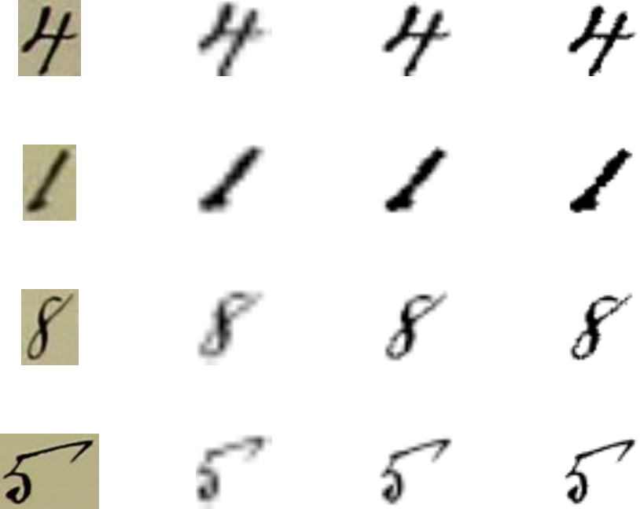

The images in Figure 1 (below) illustrate how the conversion alters the original handwritten digit image.

Changing the original color to black and white does not lead to much loss of information. For simple numbers

like 1, increasing the pixel resolution does not markedly improve the clarity of its features; there is not much

detail needed because the shape itself is just a straight line. For more complicated digits like 8, the extra

detail from increasing the resolution leads to a somewhat more marked improvement in their identiﬁability.

Increasing the resolution from 12x12 to 20x20 is a more drastic change in the image than increasing from

20x20 to 32x32, which suggests that the models for the img_20 dataset probably perform about the same as

the models for the img_32 dataset. The handwritten digits are identiﬁable to the untrained human eye at

even the lowest resolution; whether such distinctions can be made by a computer remains to be seen.

Figure 1:

An illustration of the image conversion done with ’magick.’ The images are, from left to right: the original

image, the 12x12 pixel image, the 20x20 pixel image, and the 32x32 pixel image.

3

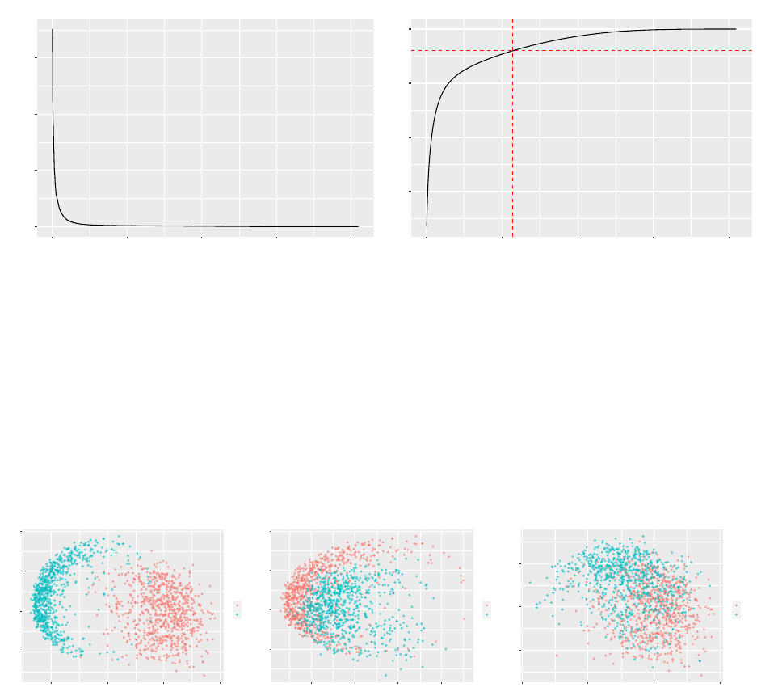

Principal Component Analysis

The img_32 dataset is composed of the converted 32x32 digit images and thus contains 1,024 covariates for

7,600 observations. Though the dimensions of the data do not present any immediate issues, training models

and performing cross-validation would be overtly computationally expensive, at least for our technological

resources. We therefore performed dimensional reduction on img_32 and trained models on that data instead.

Principal components analysis (PCA) on the img_32 data enabled us to reduce the number of predictors

from 1,024 to 286, the number of principal components that explain about 90% of the predictor variance.

However, the data is still "heavy" in the sense that the 286 columns now contain a wider range of values than

just 0 or 1, as in the original converted pixel matrix.

0.000

0.025

0.050

0.075

0 250 500 750 1000

PC

% of Variance

PCA % Variance

0.25

0.50

0.75

1.00

0 250 500 750 1000

PC

% of Variance

PCA Cumulative % Variance

Figure 2:

PCA of the img_32 data. The left plot represents the percent of variance explained by the individual

principal components, and the right plot represents the cumulative percent of variance explained by the principal

components. The red lines on the right plot show at which principal component 90% of the variance is explained.

We created a separate data frame containing just the ﬁrst 286 principal components to be used for the

construction of our classiﬁcation models.

Figure 3 shows three comparisons of the PC1 and PC2 values of diﬀerent pairs of digits. The left plot

indicates that 0 and 1 separate to form their own distinct clusters, owing to the fact that their shapes are, in

a sense, opposite; 0 is completely round, and 1 is completely straight. 1 and 7 (in the middle plot) overlap

more because 1 and 7 look somewhat similar. Likewise, the clusters of 0 and 6 overlap in the right plot.

−4

0

4

8

−5 0 5 10

PC1

PC2

y

0

1

−4

0

4

8

−5.0 −2.5 0.0 2.5

PC1

PC2

y

1

7

−4

0

4

−5 0 5 10

PC1

PC2

y

0

6

Figure 3:

Comparing PC1 and PC2 values for pairs of digits. The left plot compares digits 0 and 1, the middle plot

compares digits 1 and 7, and the right plot compares digits 0 and 6.

4

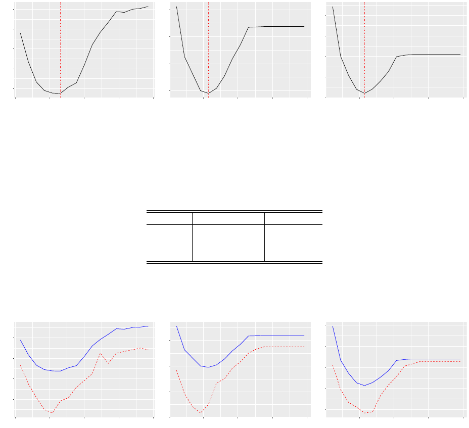

Classiﬁcation Models

Linear Support Vector Machines

To train the linear SVMs (support vector machines), we performed a grid search for the optimal cost values of

each image dataset. 5-fold cross-validation was applied to estimate the out-of-sample error, and training was

completed using the ’caret’ package. Since the response variable has 10 levels, ’caret’ automatically applies

the ’one-against-one’ approach for linear SVM classiﬁcation. The img_12 and img_20 data contain only

binary variables, and the dimensionally reduced img_32 data just contains the ﬁrst 286 principal components,

so it was not necessary to re-scale the predictor columns before training the SVMs.

0.11

0.12

0.13

0.14

0.15

−6 −3 0 3 6

log(Cost)

5−fold CV Error

0.09

0.10

0.11

0.12

−6 −3 0 3

log(Cost)

5−fold CV Error

0.12

0.14

0.16

0.18

0.20

−6 −3 0 3

log(Cost)

5−fold CV Error

Figure 4:

Linear SVM grid search plots. The left, middle, and right plots show the CV errors for the img_12,

img_20, and PCA data, respectively.

The optimal costs and test errors are summarized in Table 1. Figure 5 provides a visual comparison of the

test and 5-fold CV error across the grid of cost values. The 5-fold CV error is a decent approximation of the

test error, and our grid search gives us a good approximation of the optimal cost value.

Data Optimal Cost Test Error

img_12 0.125 0.0783

img_20 0.00390625 0.06

PCA 0.00390625 0.085

Table 1: Summary of linear SVMs

0.08

0.10

0.12

0.14

−6 −3 0 3 6

log(Cost)

Error Rate

0.05

0.07

0.09

0.11

−6 −3 0 3

log(Cost)

Error Rate

0.09

0.12

0.15

0.18

0.21

−6 −3 0 3

log(Cost)

Error Rate

Figure 5:

Comparison of linear SVM test error and 5-fold CV error. The left, middle, and right plots correspond to

the img_12, img_20, and PCA data, respectively. The red line shows the test error for each log(cost), and the blue

line shows the 5-fold CV error for each log(cost) (the same values shown in Figure 4).

5

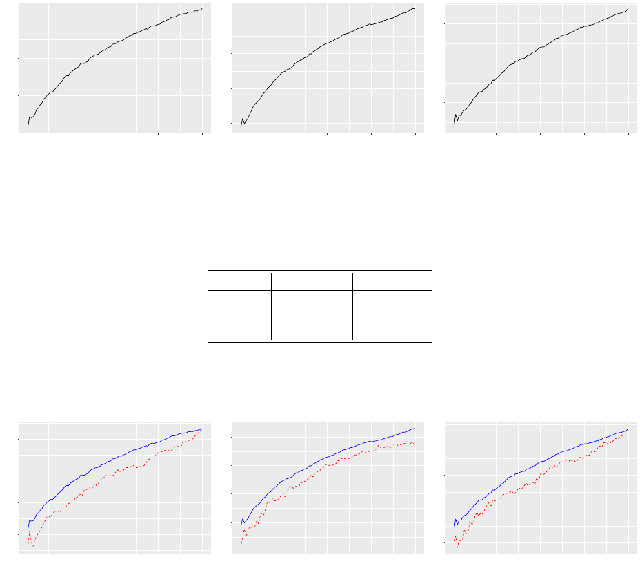

K-Nearest Neighbors

We performed another grid search to ﬁnd the optimal K values for the KNN models—again, using the ’caret’

package. As with the linear SVMs, we do not need to worry about re-scaling the predictor columns for the

KNN models.

Interestingly, the optimal K for all our data was 1; the plots in Figure 6 show that the 5-fold cross-validation

error continues to increase as K increases for all three datasets.

0.15

0.20

0.25

0 25 50 75 100

K

5−fold CV Error

0.10

0.15

0.20

0.25

0 25 50 75 100

K

5−fold CV Error

0.10

0.15

0.20

0 25 50 75 100

K

5−fold CV Error

Figure 6:

KNN grid search plots. The left, middle, and right plots show the CV errors for the img_12, img_20, and

PCA data, respectively.

Table 2 summarizes the KNN results. Figure 7 provides a comparison of the test error and CV error. The

plots in Figure 7 conﬁrm our CV results; indeed, the KNN model with K=1 gives the lowest test error.

Data Optimal K Test Error

img_12 1 0.0817

img_20 1 0.0583

PCA 1 0.0467

Table 2: Summary of KNN models

0.10

0.15

0.20

0.25

0 25 50 75 100

K

Error Rate

0.05

0.10

0.15

0.20

0.25

0 25 50 75 100

K

Error Rate

0.05

0.10

0.15

0.20

0 25 50 75 100

K

Error Rate

Figure 7:

Comparison of KNN test error and 5-fold CV error. The left, middle, and right plots correspond to the

img_12, img_20, and PCA data, respectively. The blue line represents to the 5-fold CV error at each K, and the red

line represents the test error at each K.

6

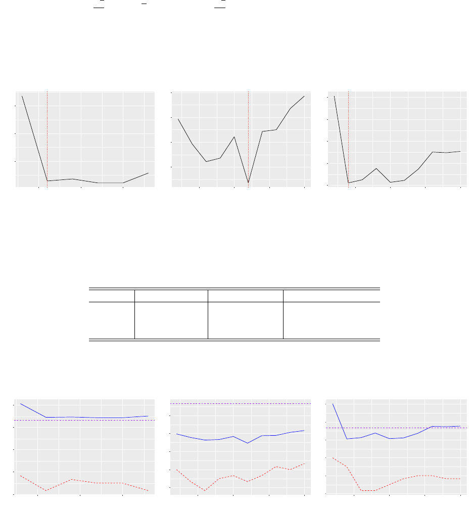

Random Forest and Bagging

Random forest models were tuned across a grid of mtry (number of variables per tree) values. Performances

were compared based on out-of-bag (OOB) error. For each dataset, the grid limits of the mtry parameter

were originally set to

√

p

2

and 3

√

p

at intervals of

√

p

2

. The grid was expanded for the img_20 data, since the

minimal OOB error was attained at 60 variables per tree. Figure 8 displays the mtry grid search results.

The random forest models were ﬁtted with the ’ranger’ algorithm, which gave us the tuning results in the

shortest time. Each random forest model includes 500 trees, the default value set by ’ranger.’ We also used

the ’ranger’ package to ﬁt bagging models for each dataset.

0.066

0.068

0.070

10 20 30

mtry

Out−of−bag Error

0.056

0.058

0.060

0.062

25 50 75 100

mtry

Out−of−bag Error

0.090

0.095

0.100

0.105

0.110

20 40 60 80

mtry

Out−of−bag Error

Figure 8:

Random forest grid search for optimal mtry. The red lines indicate the optimal mtry values. From left to

right, the plots represent the grid searches for the img_12, img_20, and PCA data.

The bagging and random forest test performances are given in Table 3. Figure 9 compares the OOB error,

random forest test error, and bagging test error.

Data Optimal mtry RF Test Error Bagging Test Error

img_12 12 0.0367 0.0633

img_20 60 0.04 0.0783

PCA 16 0.065 0.0983

Table 3: Summary of random forest and bagging models

0.03

0.04

0.05

0.06

0.07

10 20 30

mtry

Error rate

0.03

0.04

0.05

0.06

0.07

25 50 75 100

mtry

Error rate

0.06

0.07

0.08

0.09

0.10

0.11

20 40 60 80

mtry

Error rate

Figure 9:

Comparison of the random forest test error, random forest OOB error, and bagging test error. The left,

middle, and right plots correspond to the img_12, img_20, and PCA data, respectively. The red line represents the

test error for each mtry, the blue line represents the OOB error for each mtry, and the purple line represents the

bagging test error.

7

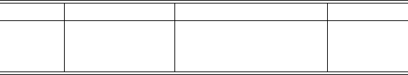

Conclusion

The best models for each dataset are summarized in the following table.

Data Best Model Optimal Parameter(s) Test Error

img_12 Random Forest mtry=12 0.0367

img_20 Random Forest mtry=60 0.04

PCA KNN K=1 0.0467

Table 4: Summary of best models for each dataset

Surprisingly, the img_12 dataset resulted in the model with the lowest test misclassiﬁcation rate of 0.0367;

the random forest models for the img_12 and img_20 datasets performed about the same on the test set.

Moreover, the best model trained on the PCA dataset, the most information-heavy dataset, had the highest

test error overall. The overall similarities in test set performance suggest that the increase in image resolution

does not noticeably improve the handwritten digit identiﬁability.

not hold. While a polynomial or radial basis may have performed better, those beneﬁts would be realized

only after a very long training period. We attempted to perform a grid search for a polynomial SVM ﬁt to

the img_12 but discovered that it would take hours just for our 144 dimension feature space, which did not

bode well for the higher dimensional, more complex img_20 and img_32 PCA datasets. Hence, we forewent

the more complex SVMs. Certainly, given a faster, multi-core computer processor that allows for parallel

processing across several cores, we would have trained and evaluated the test performance of SVMs with

nonlinear kernels.

As noted earlier, a peculiar feature of the KNN models was that, for all three of our datasets, the best model

was the single nearest neighbor model. This 1-NN model lies at one extreme of the bias-variance trade-oﬀ, and

we would typically surmise that such a model is grossly overﬁt to the training data and would consequently

not give adequate test results. However, after examining the test errors, we found that the 1-NN consistently

outperformed the other KNN models. Hence, contrary to our intuition, the 1-NN model is the best KNN

model for our data.

The main issues encountered in the project were technical; as mentioned before, we were unable to perform

grid searches for polynomial or radial SVMs because the computations would take too long. The grid search

for the random forest models initially posed a similar challenge. With the ’caret’ package’s ’train()’ function,

we ﬁrst applied the standard ’rf’ algorithm (from the ’randomForest’ package) but found that the time it

took to get the out-of-bag errors for each mtry values was too long. We then tried ’parRF’ method with

the ’train()’ function, but this alternative ﬁtting method did not drastically improve the computation time.

Finally, in our next attempt, the ’ranger’ algorithm generated the tuning results within an hour; it is for this

reason that we chose to use the ’ranger’ algorithm for all our random forest/bagging model ﬁtting.

The image processing, though at ﬁrst unfamiliar, was surprisingly simple; the ’magick’ package provided all

the basic functions we needed, and we simply had to loop through the images downloaded from the ARDIS

GitHub. This looping process required some minor string manipulation to read in the diﬀerent image ﬁles,

but that manipulation was the extent of our issues with handling the raw digit images.

8

References

A. Liaw and M. Wiener (2002). Classiﬁcation and Regression by randomForest. R News 2(3), 18–22.

David Meyer, Evgenia Dimitriadou, Kurt Hornik, Andreas Weingessel and Friedrich Leisch (2019). e1071:

Misc Functions of the Department of Statistics, Probability Theory Group (Formerly: E1071), TU Wien. R

package version 1.7-3. https://CRAN.R-project.org/package=e1071

Jeroen Ooms (2020). magick: Advanced Graphics and Image-Processing in R. R package version 2.3.

https://CRAN.R-project.org/package=magick

Huseyin Kusetogullari, Amir Yavariabdi, Abbas Cheddad, Håkan Grahn and Johan Hall, 2019, "ARDIS:

A Swedish Historical Handwritten Digit Dataset," Neural Computing and Applications, Springer. DOI:

10.1007/s00521-019-04163-3

Marvin N. Wright, Andreas Ziegler (2017). ranger: A Fast Implementation of Random Forests for High

Dimensional Data in C++ and R. Journal of Statistical Software, 77(1), 1-17. doi:10.18637/jss.v077.i01

Max Kuhn (2020). caret: Classiﬁcation and Regression Training. R package version 6.0-86. https://CRAN.R-

project.org/package=caret

Wickham et al., (2019). Welcome to the tidyverse. Journal of Open Source Software, 4(43), 1686,

https://doi.org/10.21105/joss.01686

9

[figure not shown]

Appendix

R Code for Image Processing

Function to convert image to single row given image object and resolution value.

#parameters are img object (use image_read from 'magick')

convert_to_row <- function(img, res) {

img %>%

#re-scale image

image_scale(paste(res, "x", res, "!", sep = "")) %>%

#convert to black and white

image_convert(type = 'Bilevel') %>%

image_raster() %>%

#change black to 0 and black to 1

mutate(col = ifelse(col == "#ffffffff", 1, 0)) %>%

#collapse

pivot_wider(id_cols=c("x", "y"),

names_from = c("x", "y"),

values_from = "col") %>%

return()

}

Function to convert all 760 images of a given digit into a dataframe.

#parameters are digit (0-9) and resolution (any positive integer)

ardis_data <- function(digit, res) {

#create empty dataframe

img_df = as.data.frame(matrix(NA, 760, res^2))

#set names of columns

names(img_df) = names(

#use local image file location

image_read(paste("ardis_3",

digit,

"/1.jpg",

sep = "")) %>%

convert_to_row(res))

#loop through all images stored locally and convert_to_row

#then, add to dataframe

for(i in 1:760) {

img = image_read(paste("ardis_3",

digit,

"/",

i,

".jpg",

sep = ""))

img_df[i,] = convert_to_row(img, res)

}

#create response column, y (actual digit)

img_df = img_df %>%

mutate(y = digit)

return(img_df)

}

Loop through all digits 0-9 and combine into a single dataframe, img_data. Change ‘res’ value to match

desired resolution (12, 20, and 32 already created).

10

[figure not shown]

#set resolution

res = 20

#first create dataframe of '0' digit

#simplifies looping (no need to do i-1)

img_data = ardis_data(0, res)

for(i in 1:9) {

img_data = rbind(img_data, ardis_data(i, res))

}

Write to local storage.

readr::write_csv(img_data,

path = "img_data_20.csv")

11

[figure not shown]

R Code for img_12 Models

Tried to tune linear SVM with the e1071 package, but the computation was too slow.

svm.tune = tune(svm, y ~ ., data = img[-test,], kernel = "linear", range = list(cost = c(2^(-8:8))))

Linear SVM tuning with ‘caret’ was much faster.

#svm with caret

grid = expand.grid(C = 2^(-8:8))

ctrl = trainControl(method='cv', number=5, savePred = TRUE)

svmmod = train(y~., img[-test,], method = "svmLinear",

trControl = ctrl, tuneGrid = grid)

Plot of CV error of linear SVM

#svm plot

ggplot() +

geom_line(aes(x = log(svmmod$results[,1]),

y = 1-svmmod$results[,2])) +

xlab("log(Cost)") +

ylab("5-fold CV Error") +

geom_vline(aes(xintercept = log(0.125)), linetype = "dotted",

colour = "red")

#test error

mean(predict(svmmod, img[test,]) != img[test,]$y)

SVM test error across the Cost grid

svm.error = vector()

for(i in 2^(-8:8)) {

mod = svm(y~., img[-test,], cost = i, kernel = "linear")

pred = as.vector(predict(mod, img[test, -145]))

svm.error = c(svm.error, mean(pred != img[test, 145]))

}

Overlay the SVM test and CV errors

ggplot() +

geom_line(aes(x = log(svmmod$results[,1]),

y = 1 - svmmod$results[,2]),

colour = "blue") +

geom_line(aes(x = log(svmmod$results[,1]),

y = svm.error),

linetype = "dashed", colour = "red") +

xlab("log(Cost)") +

ylab("Error Rate")

KNN training using ‘caret’ across a grid of K values

#KNN training with caret

grid = expand.grid(k = 1:100)

ctrl = trainControl(method='cv', number=5, savePred = TRUE)

knn.img = train(y~., img[-test,], method = "knn",

trControl = ctrl, tuneGrid = grid)

Plot of the K grid search

12

[figure not shown]

#plot + test error

ggplot() +

geom_line(aes(x = 1:100,

y = 1 - knn.img$results[,2])) +

xlab("K") +

ylab("5-fold CV Error")

mean(as.vector(predict(knn.img, img[test,])) != img[test,"y"])

Get KNN test errors across the grid of K

train.p = as.matrix(img[-test,-145])

train.r = as.matrix(img[-test, 145])

test.p = as.matrix(img[test, -145])

test.r = as.matrix(img[test, 145])

knn.test = numeric(100)

for(i in 1:100){

knn.test[i] = mean(knn(train = train.p, cl = train.r,

test = test.p, k = i) != test.r)

}

Overlay KNN test and CV errors

#plot of KNN CV+test error

ggplot() +

geom_line(aes(x = 1:100,

y = 1 - knn.img$results[,2]),

color = "blue") +

geom_line(aes(x = 1:100,

y = knn.test),

linetype = "dashed", color = "red") +

xlab("K") +

ylab("Error Rate")

Random Forest tuning with ‘caret.’ Range of mtry (variables selected per tree) was 6 (

√

p/

2) to 36 (3

√

p

) at

intervals of 6.

#tuning the random forest model using the caret package

grid = expand.grid(.mtry = seq(6, 36, 6),

.splitrule = "gini",

.min.node.size = 1)

ctrl = trainControl(method="oob")

rf.img = train(y~., img[-test,], method = "ranger",

trControl = ctrl, tuneGrid = grid)

RF grid search plot

#random forest graph using oob error

ggplot() +

geom_line(aes(x = rf.img$results[,3],

y = 1 - rf.img$results[,1])) +

xlab("mtry") + ylab("Out-of-bag Error") +

geom_vline(aes(xintercept = 12), linetype = "dotted",

colour = "red")

Fit random forest model based on grid search.

13

[figure not shown]

#fit rf model with best mtry based on oob

rf.img1 = ranger(y~., data = img[-test,],

mtry = 12, splitrule = "gini", min.node.size = 1)

#test error of best rf model

mean(predict(rf.img1, img[test,])[["predictions"]] != img[test,]$y)

Get test errors over mtry grid

rf.error = vector()

for(i in seq(6, 36, 6)) {

mod = ranger(y~., data = img[-test,],

mtry = i, splitrule = "gini", min.node.size = 1)

pred = predict(mod, img[test,])[["predictions"]]

rf.error = c(rf.error, mean(pred != img[test,]$y))

}

Use ‘ranger’ to get a bagging model.

#bagging with ranger package

bag.img = ranger(y~., data = img[-test,],

mtry = 144, splitrule = "gini", min.node.size = 1)

bag.error = mean(predict(bag.img, img[test,])[["predictions"]] != img[test,]$y)

Overlay test and CV errors of RF and bagging models

#CV + test error

ggplot() +

geom_line(aes(x = rf.img$results[,3],

y = 1 - rf.img$results[,1]),

colour = "blue") +

geom_line(aes(x = rf.img$results[,3],

y = rf.error),

linetype = "dashed", colour = "red") +

geom_hline(aes(yintercept = bag.error),

colour = "purple", linetype = "dashed") +

xlab("mtry") +

ylab("Error rate")

14

[figure not shown]

R Code for img_20 Models

‘caret’ svm training of linear SVM

#svm training with caret

grid = expand.grid(C = 2^(-12:4))

ctrl = trainControl(method='cv', number=5, savePred = TRUE)

svmmod = train(y~., img[-test,], method = "svmLinear",

trControl = ctrl, tuneGrid = grid)

Plot of CV error of linear SVM

#plot + test error

ggplot() +

geom_line(aes(x = log(svmmod$results[,1]),

y = 1 - svmmod$results[,2])) +

xlab("log(Cost)") +

ylab("5-fold CV Error") +

geom_vline(aes(xintercept = log(0.00390625)), linetype = "dotted",

colour = "red")

#mean(predict(svmmod, img[test,]) != img[test,]$y)

SVM test error across the Cost grid

svm.error = vector()

for(i in 2^(-12:4)) {

mod = svm(y~., img[-test,], cost = i, kernel = "linear")

pred = as.vector(predict(mod, img[test, -401]))

svm.error = c(svm.error, mean(pred != img[test, 401]))

}

Overlay the SVM test and CV errors

ggplot() +

geom_line(aes(x = log(svmmod$results[,1]),

y = 1 - svmmod$results[,2]),

colour = "blue") +

geom_line(aes(x = log(svmmod$results[,1]),

y = svm.error),

linetype = "dashed", colour = "red") +

xlab("log(Cost)") +

ylab("Error Rate")

KNN tuning with ‘caret’

#knn training with caret

grid = expand.grid(k = 1:100)

ctrl = trainControl(method='cv', number=5, savePred = TRUE)

knn.img = train(y~., img[-test,], method = "knn",

trControl = ctrl, tuneGrid = grid)

Plot of the K grid search

#plot + test error

ggplot() +

geom_line(aes(x = knn.img$results[,1],

y = 1 - knn.img$results[,2])) +

xlab("K") +

15

[figure not shown]

ylab("5-fold CV Error")

#mean(as.vector(predict(knn.img, img[test,])) != img[test,"y"])

Get KNN test errors across the grid of K

train.p = as.matrix(img[-test,-401])

train.r = as.matrix(img[-test, 401])

test.p = as.matrix(img[test, -401])

test.r = as.matrix(img[test, 401])

knn.test = numeric(100)

for(i in 1:100){

knn.test[i] = mean(knn(train = train.p, cl = train.r,

test = test.p, k = i) != test.r)

}

Plot KNN CV and test errors

#plot of KNN CV+test error

ggplot() +

geom_line(aes(x = 1:100,

y = 1 - knn.img$results[,2]),

color = "blue") +

geom_line(aes(x = 1:100,

y = knn.test),

linetype = "dashed", color = "red") +

xlab("K") +

ylab("Error Rate")

Random forest training with ‘caret’ using ‘ranger’ ﬁtting algorithm

#random forest training with caret

#set grid

#grid values set the same way as in img_12 (look at .rmd for img_12 for specifics).

grid = expand.grid(.mtry = seq(10, 100, 10),

.splitrule = "gini",

.min.node.size = 1)

#set control to 5-fold CV

ctrl = trainControl(method="oob")

rf.img = train(y~., img[-test,], method = "ranger",

trControl = ctrl, tuneGrid = grid)

OOB error plot

#random forest graph using oob error

ggplot() +

geom_line(aes(x = rf.img$results[,3],

y = 1 - rf.img$results[,1])) +

xlab("mtry") + ylab("Out-of-bag Error") +

geom_vline(aes(xintercept = 60), linetype = "dotted",

colour = "red")

Fit random forest model with optimal mtry

#fit rf model with best mtry based on oob

rf.img1 = ranger(y~., data = img[-test,],

mtry = 60, splitrule = "gini", min.node.size = 1)

16

[figure not shown]

#test error of best rf model

mean(predict(rf.img1, img[test,])[["predictions"]] != img[test,]$y)

Get test errors across mtry grid

rf.error = vector()

for(i in seq(10, 100, 10)) {

mod = ranger(y~., data = img[-test,],

mtry = i, splitrule = "gini", min.node.size = 1)

pred = predict(mod, img[test,])[["predictions"]]

rf.error = c(rf.error, mean(pred != img[test,]$y))

}

Bagging model with ‘ranger’

#bagging

bag.img = ranger(y~., data = img[-test,],

mtry = 400, splitrule = "gini", min.node.size = 1)

bag.error = mean(

predict(bag.img, img[test,])[["predictions"]] != img[test,]$y)

Plot CV and test errors for RF+bagging models

#CV + test error

ggplot() +

geom_line(aes(x = rf.img$results[,3],

y = 1 - rf.img$results[,1]),

colour = "blue") +

geom_line(aes(x = rf.img$results[,3],

y = rf.error),

linetype = "dashed", colour = "red") +

geom_hline(aes(yintercept = bag.error),

colour = "purple", linetype = "dashed") +

xlab("mtry") +

ylab("Error rate")

17

[figure not shown]

R Code for img_32 PCA and PCA Models

Principal component analysis of the img_32 data.

img.pca <- prcomp(img[,-1025])

#calculate percent variance explained

pV = img.pca$sdev^2/sum(img.pca$sdev^2)

#calculate PC at which cumulative % variance explained is 90%

at90 = which.min(abs(.9 - cumsum(pV)))

PCA plots

#% variance for each PC

ggplot() +

geom_line(aes(x = 1:1024, y = pV)) +

xlab("PC") +

ylab("% of Variance") +

ggtitle("PCA % Variance")

#cumulative % variance

ggplot() +

geom_line(aes(x = 1:1024, y = cumsum(pV))) +

geom_hline(aes(yintercept = 0.9), linetype = "dashed",

colour = "red") +

geom_vline(aes(xintercept = at90), linetype = "dashed",

colour = "red") +

xlab("PC") +

ylab("% of Variance") +

ggtitle("PCA Cumulative % Variance")

Create dataframe of ﬁrst 286 PCs

pca.df = as.data.frame(img.pca$x[,1:286]) %>%

cbind(img[,"y"])

Graphically compare ﬁrst two PCs of two digits

pca.df %>%

filter(y==1 | y==0) %>%

ggplot() +

geom_point(aes(x = PC1, y = PC2, colour = y), alpha = 0.5)

Linear SVM training

#svm training with caret

grid = expand.grid(C = 2^(-12:4))

ctrl = trainControl(method='cv', number=5, savePred = TRUE)

svmmod = train(y~., pca.df[-test,], method = "svmLinear",

trControl = ctrl, tuneGrid = grid)

Plot SVM grid search

#plot + test error

ggplot() +

geom_line(aes(x = log(svmmod$results[,1]),

y = 1 - svmmod$results[,2])) +

xlab("log(Cost)") +

18

[figure not shown]

ylab("5-fold CV Error") +

geom_vline(aes(xintercept = log(0.00390625)), linetype = "dotted",

colour = "red")

#mean(predict(svmmod, pca.df[test,]) != pca.df[test,]$y)

Get Cost grid test errors

svm.error = vector()

for(i in 2^(-12:4)) {

mod = svm(y~., pca.df[-test,], cost = i, kernel = "linear")

pred = as.vector(predict(mod, pca.df[test, -287]))

svm.error = c(svm.error, mean(pred != pca.df[test, 287]))

}

Plot SVM test+CV error

ggplot() +

geom_line(aes(x = log(svmmod$results[,1]),

y = 1 - svmmod$results[,2]),

colour = "blue") +

geom_line(aes(x = log(svmmod$results[,1]),

y = svm.error),

linetype = "dashed", colour = "red") +

xlab("log(Cost)") +

ylab("Error Rate")

KNN training

#knn training with caret

grid = expand.grid(k = 1:100)

ctrl = trainControl(method='cv', number=5, savePred = TRUE)

knn.img = train(y~., pca.df[-test,], method = "knn",

trControl = ctrl, tuneGrid = grid)

Plot grid search for KNN

#plot + test error

ggplot() +

geom_line(aes(x = knn.img$results[,1],

y = 1 - knn.img$results[,2])) +

xlab("K") +

ylab("5-fold CV Error")

#mean(predict(knn.img, pca.df[test,]) != pca.df[test,]$y)

Get KNN test errors across grid of K

train.p = as.matrix(pca.df[-test, -287])

train.r = as.matrix(pca.df[-test, 287])

test.p = as.matrix(pca.df[test, -287])

test.r = as.matrix(pca.df[test, 287])

knn.test = numeric(100)

for(i in 1:100){

knn.test[i] = mean(knn(train = train.p, cl = train.r,

test = test.p, k = i) != test.r)

19

[figure not shown]

}

Plot KNN CV and test error

#plot of KNN CV+test error

ggplot() +

geom_line(aes(x = 1:100,

y = 1 - knn.img$results[,2]),

color = "blue") +

geom_line(aes(x = 1:100,

y = knn.test),

linetype = "dashed", color = "red") +

xlab("K") +

ylab("Error Rate")

Tune random forest across grid of mtry

#random forest training with caret

#set grid

#grid values set the same way as in img_12

grid = expand.grid(.mtry = seq(8, 80, 8),

.splitrule = "gini",

.min.node.size = 1)

#set control to 5-fold CV

ctrl = trainControl(method="oob")

rf.img = train(y~., pca.df[-test,], method = "ranger",

trControl = ctrl, tuneGrid = grid)

Plot mtry grid search

#plot + test error

ggplot() +

geom_line(aes(x = rf.img$results[,3],

y = 1 - rf.img$results[,1])) +

xlab("mtry") + ylab("Out-of-bag Error") +

geom_vline(aes(xintercept = 16), linetype = "dotted",

colour = "red")

Fit best random forest model

#fit rf model with best mtry based on oob

rf.img1 = ranger(y~., data = pca.df[-test,],

mtry = 16, splitrule = "gini", min.node.size = 1)

#test error of best rf model

mean(predict(rf.img1, pca.df[test,])[["predictions"]]

!= pca.df[test,]$y)

Get test errors of random forest models across mtry grid

rf.error = vector()

for(i in seq(8, 80, 8)) {

mod = ranger(y~., data = pca.df[-test,],

mtry = i, splitrule = "gini", min.node.size = 1)

pred = predict(mod, pca.df[test,])[["predictions"]]

rf.error = c(rf.error, mean(pred != img[test,]$y))

}

20

[figure not shown]

Also ﬁt bagging model

#bagging

bag.img = ranger(y~., data = pca.df[-test,],

mtry = 286, splitrule = "gini", min.node.size = 1)

bag.error = mean(

predict(bag.img, pca.df[test,])[["predictions"]] !=

pca.df[test,]$y)

Plot bagging test error, rf test error, and rf CV error across grid

#CV + test error

ggplot() +

geom_line(aes(x = rf.img$results[,3],

y = 1 - rf.img$results[,1]),

colour = "blue") +

geom_line(aes(x = rf.img$results[,3],

y = rf.error),

linetype = "dashed", colour = "red") +

geom_hline(aes(yintercept = bag.error),

colour = "purple", linetype = "dashed") +

xlab("mtry") +

ylab("Error rate")

21